# Analiza danych grupy C

Mateusz Broczkowski, Filip Michewicz, Dawid Skowroński, Wiktor Niedźwiedzki, Jakub Wiszniewski

2025-01-24

Tabela z ofertami

| Oferta | Nazwa wycieczki |
| --- | --- |
| 1 | Survival z węgierskim poradnikiem przetrwania |
| 2 | Babciowy escape room, czyli ucieczka przed kolejną dokładką |
| 3 | Poszukiwanie Świętego Górala |
| 4 | Niespodziewana rekonstrukcja hiszpańskiej inkwizycji |
| 5 | Skok za spadochronem |
| 6 | Konkurs na najlepszy tuning Polonez |
| 7 | Wyścigi ‘Maluchów’ z silnikami V8 |
| 8 | Misja szpiegowska: infiltracja opuszczonej kamienicy w stroju Lajkonika |
| 9 | Misja szpiegowska: Tajna misja w pełnej zbroi płytowej |
| 10 | Konkurs kulinarny: Najdziwniejszy kebab |
| 11 | Konkurs kulinarny: 101 dań z cebuli |
| 12 | Konkurs kulinarny: Niedorzeczne połączenia |
| 13 | Zwiedzanie ogrodu botanicznego w masce przeciwgazowej |
| 14 | Skok na grzybobranie (dosłownie) |
| 15 | Nocne grzybobranie w noktowizorach |
| 16 | Grzybobranie na poligonie wojskowym |
| 17 | Grzybobranie podczas inscenizacji polowania |
| 18 | Golf na szczudłach |
| 19 | Karaoke na helu |
| 20 | Wyścig w wózkach sklepowych |
| 21 | Metalowy koncert na lirze korbowej i burczybasie |
| 22 | Wycieczka rowerowa z Ojcem Matateusz |
| 23 | Pomysł na najbardziej niedorzeczne ministerstwo |
| 24 | Kurs normalizacji baz danych w języku chińskim |
| 25 | Noc RPGów, ale to liczby zespolone |
| 26 | Grzybobranie na szczudłach |
| 27 | Konkurs na najbardziej zbędny gadżet |
| 28 | Konkurs jedzenia kiszonego śledzia |
| 29 | Najlepsze przebranie za znak drogowy |
| 30 | Półmaraton w strojach T-Rexa |
| 31 | Noc gier planszowych ze zmianą miejsc |
| 32 | Szachy warcabami |
| 33 | Gra Łasicy |
| 34 | Walka na szable w okularach zniekształcających rzeczywistość |
| 35 | Ucieczka z więzienia w stroju klauna |

# 1 Znajdź najpopularniejsze rodzaje wycieczek, porównaj koszta i zyski, czy są opłacalne?

Tabela z posortowanymi wycieczkami względem ich popularności

| Nazwa wycieczki | Liczba wycieczek | Liczba uczestników | Koszt | Przychód | Zysk |
| --- | --- | --- | --- | --- | --- |
| Misja szpiegowska: Tajna misja w pełnej zbroi płytowej | 15 | 593 | 624050 | 889500 | 265450 |
| Najlepsze przebranie za znak drogowy | 15 | 575 | 117500 | 138000 | 20500 |
| Półmaraton w strojach T-Rexa | 15 | 651 | 127650 | 162750 | 35100 |
| Poszukiwanie Świętego Górala | 14 | 535 | 475000 | 802500 | 327500 |
| Konkurs na najlepszy tuning Polonez | 14 | 547 | 971900 | 1367500 | 395600 |
| Walka na szable w okularach zniekształcających rzeczywistość | 13 | 517 | 76370 | 103400 | 27030 |
| Zwiedzanie ogrodu botanicznego w masce przeciwgazowej | 12 | 533 | 101940 | 133250 | 31310 |
| Grzybobranie podczas inscenizacji polowania | 12 | 481 | 59475 | 105820 | 46345 |
| Karaoke na helu | 12 | 499 | 109900 | 174650 | 64750 |
| Metalowy koncert na lirze korbowej i burczybasie | 12 | 474 | 128880 | 165900 | 37020 |
| Ucieczka z więzienia w stroju klauna | 12 | 483 | 118260 | 154560 | 36300 |
| Kurs normalizacji baz danych w języku chińskim | 11 | 461 | 350930 | 461000 | 110070 |
| Grzybobranie na szczudłach | 11 | 429 | 67045 | 90090 | 23045 |
| Misja szpiegowska: infiltracja opuszczonej kamienicy w stroju Lajkonika | 10 | 397 | 236500 | 357300 | 120800 |
| Wyścig w wózkach sklepowych | 10 | 411 | 109310 | 135630 | 26320 |
| Konkurs jedzenia kiszonego śledzia | 10 | 372 | 47200 | 55800 | 8600 |
| Survival z węgierskim poradnikiem przetrwania | 9 | 376 | 369000 | 564000 | 195000 |
| Wyścigi ‘Maluchów’ z silnikami V8 | 9 | 345 | 228000 | 345000 | 117000 |
| Gra Łasicy | 9 | 354 | 31572 | 42480 | 10908 |
| Konkurs kulinarny: Niedorzeczne połączenia | 8 | 289 | 47660 | 63580 | 15920 |
| Skok na grzybobranie (dosłownie) | 8 | 329 | 242035 | 427700 | 185665 |
| Nocne grzybobranie w noktowizorach | 8 | 305 | 96325 | 122000 | 25675 |
| Golf na szczudłach | 8 | 326 | 88400 | 110840 | 22440 |
| Pomysł na najbardziej niedorzeczne ministerstwo | 8 | 306 | 53400 | 64260 | 10860 |
| Babciowy escape room, czyli ucieczka przed kolejną dokładką | 7 | 287 | 47810 | 100450 | 52640 |
| Konkurs kulinarny: 101 dań z cebuli | 7 | 281 | 39310 | 56200 | 16890 |
| Grzybobranie na poligonie wojskowym | 7 | 263 | 36525 | 47340 | 10815 |
| Wycieczka rowerowa z Ojcem Matateusz | 7 | 269 | 46870 | 67250 | 20380 |
| Noc RPGów, ale to liczby zespolone | 7 | 303 | 45230 | 66660 | 21430 |
| Konkurs na najbardziej zbędny gadżet | 7 | 289 | 49900 | 60690 | 10790 |
| Niespodziewana rekonstrukcja hiszpańskiej inkwizycji | 6 | 253 | 174500 | 303600 | 129100 |
| Noc gier planszowych ze zmianą miejsc | 6 | 240 | 33000 | 48000 | 15000 |
| Konkurs kulinarny: Najdziwniejszy kebab | 5 | 211 | 39760 | 56970 | 17210 |
| Szachy warcabami | 5 | 204 | 15280 | 20400 | 5120 |
| Skok za spadochronem | 4 | 169 | 120700 | 202800 | 82100 |

Na powyższej tabeli możemy zauważyć, że najpopularniejszymi wycieczkami są **Misja szpiegowska: Tajna misja w pełnej zbroi płytowej, Najlepsze przebranie za znak drogowy, Półmaraton w strojach T-Rexa**, które odbyły się **15** razy, a najmniej popularną wycieczką jest **Skok za spadochronem**, która odbyła się tylko **4** razy.

Średni zysk ze wszystkich wycieczek wynosi **72590**.

Do najbardziej opłacalnych wycieczek z tabeli powyżej *(czyli mających zysk ponad 2 razy większy od średniej)* należą: **Misja szpiegowska: Tajna misja w pełnej zbroi płytowej, Poszukiwanie Świętego Górala, Konkurs na najlepszy tuning Polonez, Survival z węgierskim poradnikiem przetrwania, Skok na grzybobranie (dosłownie)**.

Do najmniej opłacalnych wycieczek z tabeli powyżej *(czyli mających zysk ponad 3 razy mniejszy od średniej)* należą: **Najlepsze przebranie za znak drogowy, Grzybobranie na szczudłach, Konkurs jedzenia kiszonego śledzia, Gra Łasicy, Konkurs kulinarny: Niedorzeczne połączenia, Golf na szczudłach, Pomysł na najbardziej niedorzeczne ministerstwo, Konkurs kulinarny: 101 dań z cebuli, Grzybobranie na poligonie wojskowym, Wycieczka rowerowa z Ojcem Matateusz, Noc RPGów, ale to liczby zespolone, Konkurs na najbardziej zbędny gadżet, Noc gier planszowych ze zmianą miejsc, Konkurs kulinarny: Najdziwniejszy kebab, Szachy warcabami**.

# 2 Sporządź wykres liczby obsłużonych klientów w każdym miesiącu działalności firmy, czy firma rośnie, czy podupada?

W analizie ograniczamy się do stycznia 2025 roku, aby mieć pełen zbiór informacji o liczbie klientów i zyskach w każdym miesiącu. Część wycieczek zaplanowanych na luty i marzec, w roku 2025, nie jest opłacona, stąd nie możemy wysnuć jednoznacznych wniosków.

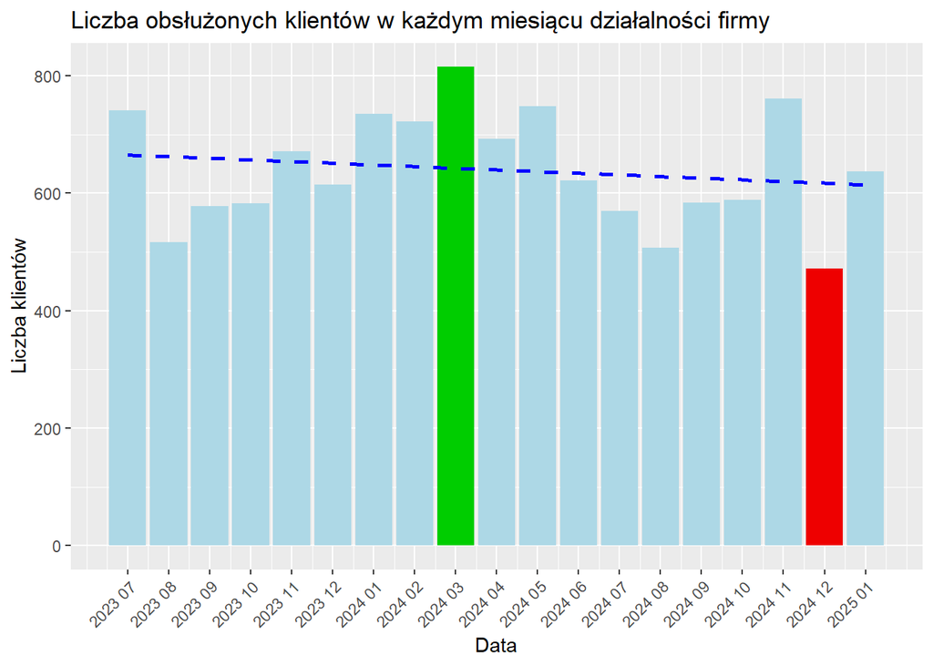

Na powyższym wykresie możemy zauważyć trend malejący liczby obsłużonych klientów w analizowanym przedziale. Największa wartość **815** jest osiągana w miesiącach: **mar 2024**. Najmniejsza wartość to natomiast **471** i jest osiągana w miesiącach: **gru 2024**.

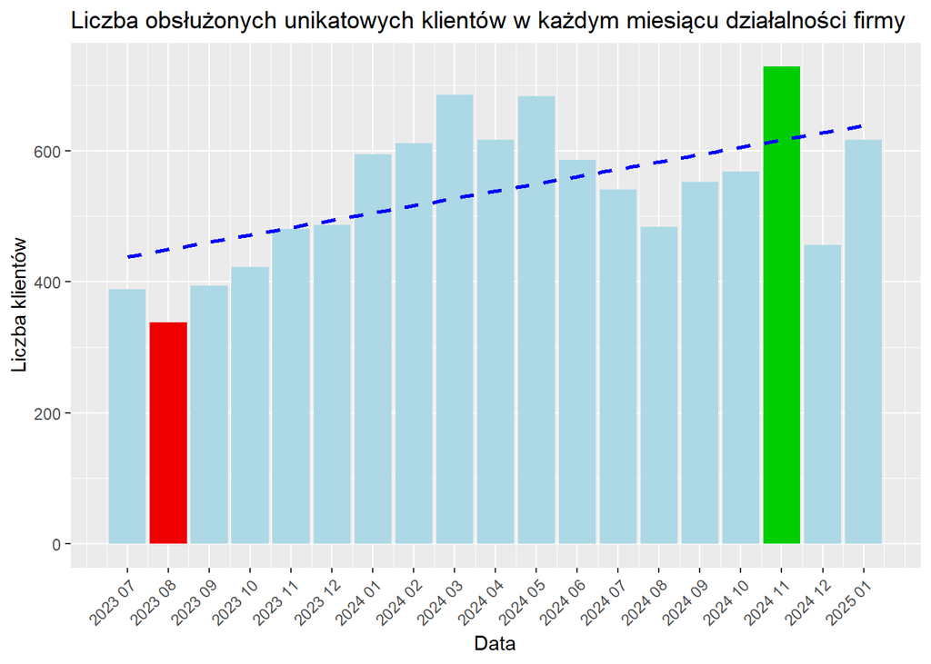

Biorąc pod uwagę jedynie unikatowych klientów w danym miesiącu, tzn. liczymy jedynie udział danego klienta w jakiejkolwiek wycieczce w miesiącu, możemy zauważyć trend rosnący liczby obsłużonych klientów w analizowanym przedziale. Największa liczba obsłużonych unikatowych klientów **728** jest osiągana w miesiącach: lis 2024. Najmniejsza wartość to natomiast **338** i jest osiągana w miesiącach: sie 2023.

Miesięczne opłaty pracowników firmy

| Liczba pracowników | Miesięczne opłaty wynagrodzeń |
| --- | --- |
| 15 | 97050 |

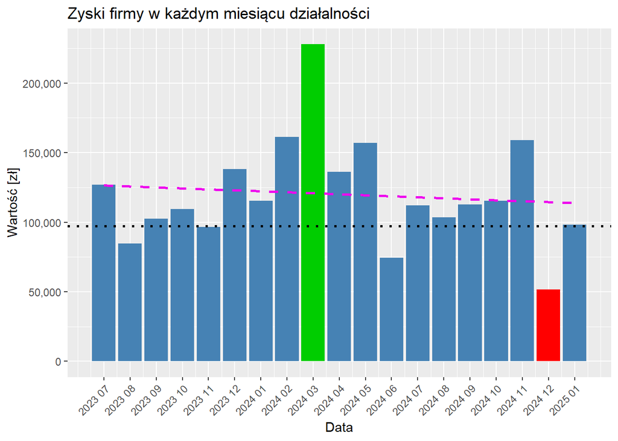

Analizując zyski możemy zauważyć trend malejący zysków firmy w analizowanym przedziale. Największy zysk (**227940** zł) firma uzyskała w miesiacach: mar 2024. Najmniejszy zysk (**51560** zł) zanotowano w miesiącach: gru 2024.Czarna kropkowana linia na wykresie wyznacza sumę wartości wszystkich wypłat pracowników w danym miesiącu. W 4 miesiącach zyski nie wystarczyły do opłacenia pracowników.

# 3 Sprawdź, po których wycieczkach klienci wracają na kolejne, a po których mają dość i więcej ich nie widzicie. Czy są takie, które być może powinny zniknąć z oferty?

Poniższy wykres przedstawia histogram współczynników powrotów klientów z wycieczek definiowany jako:

$$Współczynnik\ powrotu = 1 -
\frac{\text{Liczba klientów, dla których dana oferta była
ostatnią}}{\text{Liczba klientów, którzy uczestniczyli kiedykolwiek w
tej ofercie}}$$

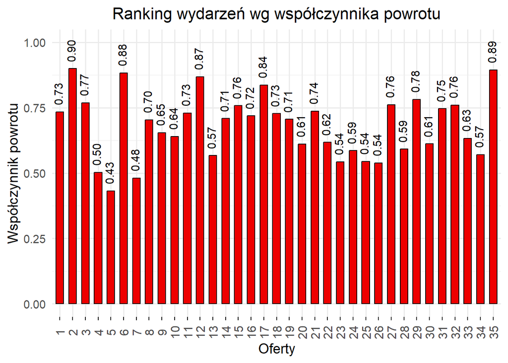

Wycieczką, po której najwięcej klientów wraca, jest Babciowy escape room, czyli ucieczka przed kolejną dokładką, dla której współczynnik powrotu wynosi 0.899. W związku z tym powinniśmy promować ją jako idealną ofertę dla początkujących turystów.

Z kolei wycieczka Skok za spadochronem, dla której współczynnik powrotu wynosi 0.432, powoduje, że wielu klientów decyduje się na rezygnację z dalszego korzystania z naszych usług.

Średni współczynnik powrotu dla wszystkich wycieczek wynosi 0.6811.

Współczynnik powrotu wycieczki, która jest najmniej popularna, stanowi 63.43% średniej wartości współczynnika powrotu w całej ofercie. Nie ma obecnie wystarczających przesłanek, by wykluczyć tę wycieczkę z oferty.

Należy jednak zwrócić uwagę na fakt że znaczna część naszych klientów odbyła jedną lub dwie wycieczki co zostało przedstawione w poniższej tabeli.

Tabela z wycieczkami i procentem skumulowanych osób

| Wycieczki na osobę | Liczba osób | Procent skumulowany |
| --- | --- | --- |
| 1 | 2228 | 45.29 |
| 2 | 1044 | 66.52 |
| 3 | 542 | 77.54 |
| 4 | 295 | 83.53 |
| 5 | 200 | 87.60 |
| 6 | 139 | 90.42 |
| 7 | 105 | 92.56 |
| 8 | 103 | 94.65 |
| 9 | 77 | 96.22 |
| 10 | 65 | 97.54 |
| 11 | 47 | 98.50 |
| 12 | 31 | 99.13 |
| 13 | 15 | 99.43 |
| 14 | 14 | 99.72 |
| 15 | 8 | 99.88 |
| 16 | 4 | 99.96 |
| 17 | 1 | 99.98 |
| 18 | 1 | 100.00 |

Jak widać w tabeli aż 77.54% naszych klientów wzieło udział w trzech lub mniejszej liczbie wycieczek.

# 4 Który plan wycieczek i która konkretna wycieczka mają najlepszą, a które najgorszą średnią ocenę? Czy warto zrezygnować z najgorzej ocenianej oferty?

Najgorzej oceniane wycieczki

| ID wycieczki | Nazwa wycieczki | Średnia ocena |
| --- | --- | --- |
| 120 | Gra Łasicy | 3.24 |
| 219 | Poszukiwanie Świętego Górala | 3.27 |
| 191 | Nocne grzybobranie w noktowizorach | 3.28 |

Najgorzej oceniana wycieczka to 120; Ocena: 3.24.

Najlepiej oceniane wycieczki

| ID wycieczki | Nazwa wycieczki | Średnia ocena |
| --- | --- | --- |
| 94 | Wyścig w wózkach sklepowych | 4.57 |
| 9 | Skok na grzybobranie (dosłownie) | 4.52 |
| 290 | Golf na szczudłach | 4.42 |

Najlepiej oceniana wycieczka to 94; Ocena: 4.57.

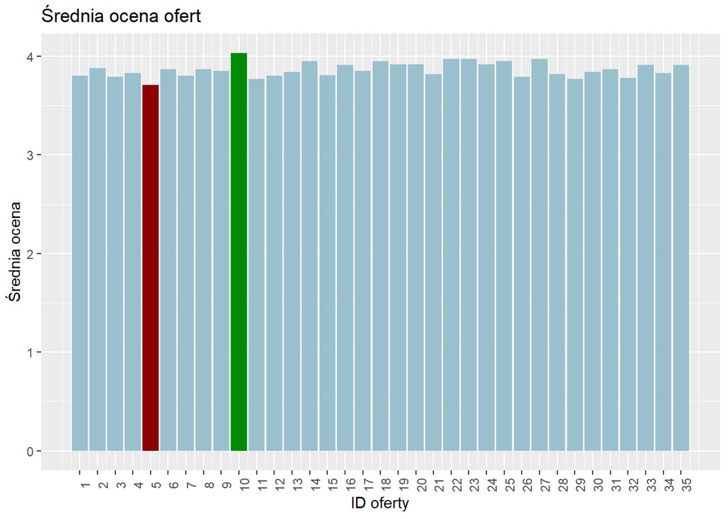

Najlepsza ocena oferty (oznaczona na zielono) to 4.03.  
Najgorsza ocena oferty (oznaczona na czerwono) to 3.71, ale nie jest za niska, warto po prostu wprowadzić w niej pewne zmiany.

# 5 Czy są nieodpowiedzialni klienci, który pojechali na wycieczkę z osobą, którą mają podaną jako osobę kontaktową w przypadku wypadku?

Na szczęście nie ma tak nieodpowiedzialnych klientów.

# 6 Którzy koordynatorzy i fotografowie przyczynili się do największych zysków firmy? Komu powinniśy dać podwyżkę?

W tej części przeanalizujmy, jak plasowały się zarobki naszych pracowników każdego miesiaca, oraz który koordynator i fotograf uczestniczył w najbardziej zyskownych wycieczkach.

Poniższy histogram ilustruje łączny zysk każdej wycieczki, w której uczestniczył dany koordynator, w poszczególnych miesiącach. Widać, że jedynymi wyraźnymi zmianami są okresy, gdy niektórzy pracownicy brali udział w wyjątkowo dochodowych lub mniej rentownych wycieczkach. Poza tymi momentami, zmiany zysków są trudne do zaobserwowania.

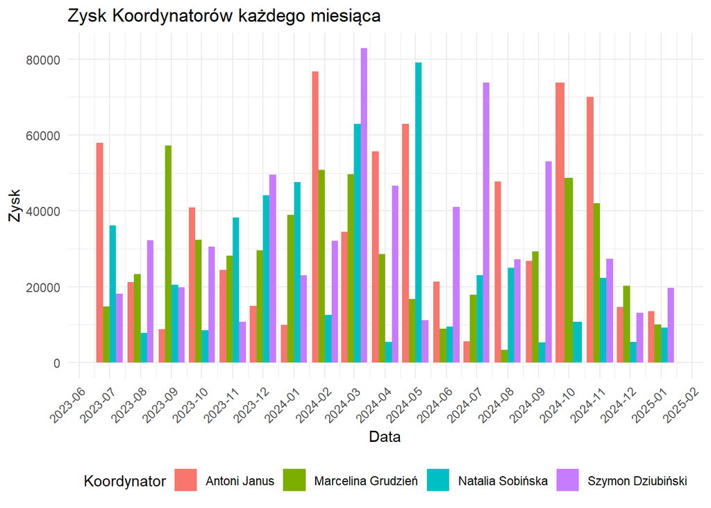

Zestawmy teraz łączny zysk każdego koordynatora od momentu rozpoczęcia pracy. To pozwoli nam zobaczyć ogólny wpływ ich działalności na wyniki finansowe, uwzględniając wszystkie wycieczki, w których brali udział, od samego początku ich pracy.

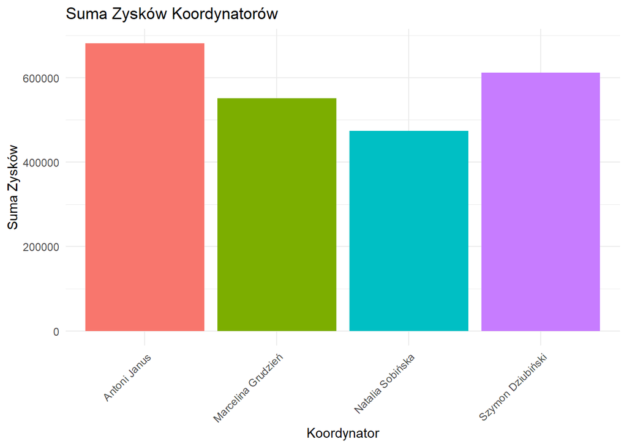

Jak się okazuje, największe zarobki osiągnęła osoba koordynująca Antoni Janus, której łączny zarobek wyniósł 681869 złotych. Z kolei najmniejsze zarobki miała osoba koordynująca Natalia Sobińska, której łączny zarobek wyniósł jedynie 473645 złotych.

Jako że każdy pracownik jest zatrudniony na takich samych warunkach i otrzymuje taką samą wypłatę, to premię powinna dostać osoba koordynująca Antoni Janus.

Dokonajmy takiej samej analizy dla fotografów.

Poniższy histogram ilustruje łączny zysk każdej wycieczki, w której uczestniczył dany fotograf, w poszczególnych miesiącach.

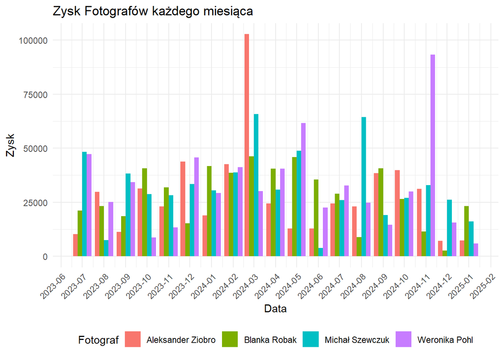

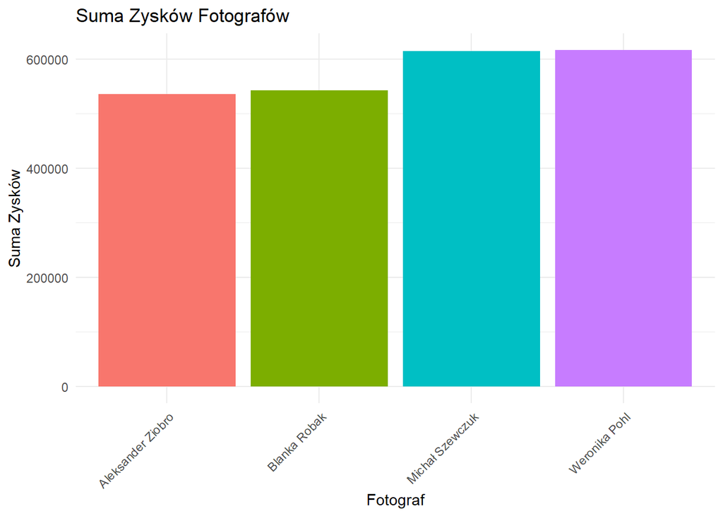

Spośród fotografów największy zarobek zawdzięczamy Weronika Pohl, wynoszący 616536 złotych. Najgorszy natomiast Aleksander Ziobro, wynoszący 535295 złotych.

Warto jednak pamiętać, że zysk firmy nie jest wynikiem tylko ich pracy – to efekt zaangażowania wszystkich pracowników.

# 7 Na jakie plany wycieczek nowi klienci decydują się najczęściej, a na jakie weterani wycieczek?

Wcześniej analizowaliśmy, ile osób po pierwszej wycieczce decyduje się na kolejne, ale która oferta przyciąga do nas najwięcej nowych klientów?

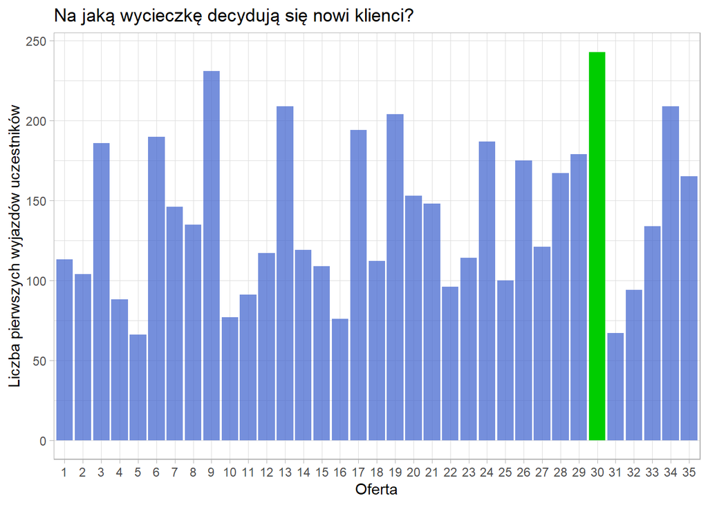

Można zauważyć, że najpopularniejszą wycieczką dla nowych klientów jest Półmaraton w strojach T-Rexa. Spośród 4919 osób wybrało ją aż 243 klientów!

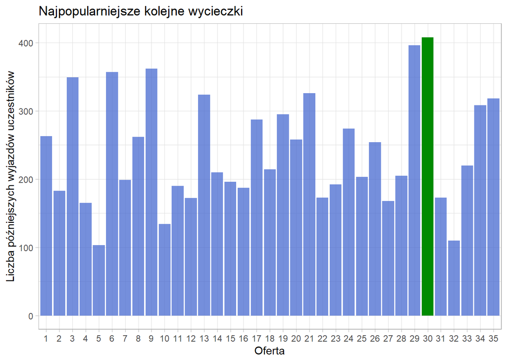

Ciemniejszym zielonym zaznaczona jest oferta “Półmaraton w strojach T-Rexa”, która jest wybierana przez klientów, którzy odbyli już u nas wcześniej wycieczki. Możemy spróbować bardziej rozpromować te oraz być może podobne oferty.

# 8 Planujemy nowy plan marketingowy, majacy na celu zwiększyć liczbę klientów. Którzy klienci dawno nie pojechali na żadną wycieczkę i powinni być targetem celu marketingowego?

Poniższy wykres przedstawia histogram liczby klientów w zależności od liczby dni, które upłynęły od ich ostatniej wycieczki. Argumenty ujemne oznaczają klientów, którzy są zaplanowani na wycieczki w przyszłości.

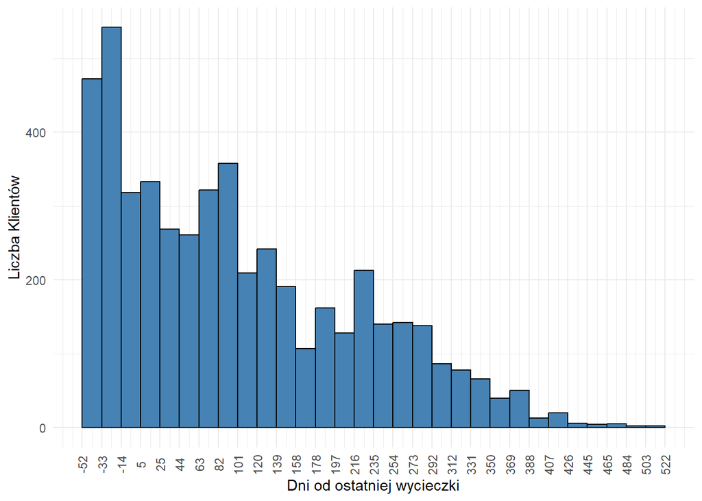

Te same wyniki zostały przedstawione w tabeli.

[output not shown]

# 9 Którzy pracownicy mieli urlopy w momentach największej organizacji wycieczek? Czy ich nieobecność wpłynęła na jakość obsługi lub organizację? Czy powinniśmy zatrudnić nowego pracownika?

Na poniższym wykresie przedstawiono zależność liczby pracowników na wyjeździe, na urlopie, na wyjeździe lub na urlopie oraz średnią ruchomą z pięciu dni wstecz i w przód.

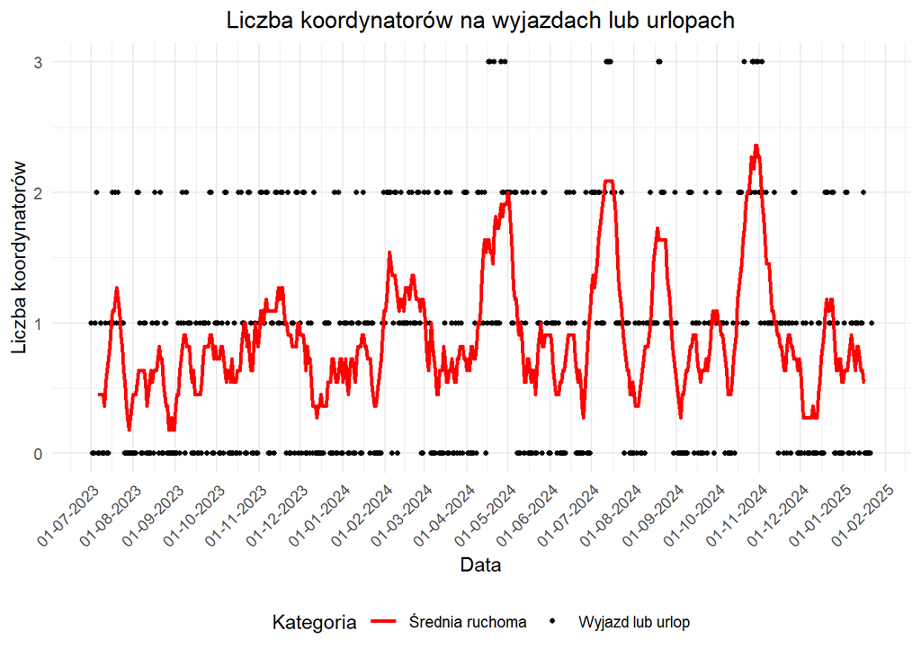

Średnia liczba koordynatorów na wycieczkach lub urlopach oscyluje wokół wartości średniej 0.88. Natomiast dni kiedy to każdy koordynator był czymś zajęty (wyjazdem lub urlopem) wynosi 0.

Dokonajmy podobnej analizy dla fotografów.

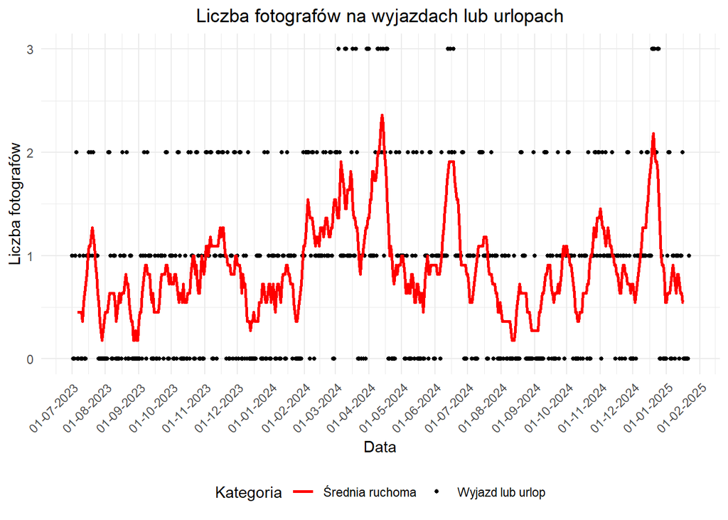

Średnia liczba fotografów na wycieczkach lub urlopach oscyluje wokół wartości średniej 0.88. Natomiast dni kiedy to każdy koordynator był czymś zajęty (wyjazdem lub urlopem) wynosi 0.